# Week 9 TidyVerse/GitHub CREATE assignment

### Explanation of the Code:

- `mutate()`: This is part of `dplyr` and allows you to create or transform columns in the dataset. Here, we use `mutate()` to create the `TotalAlcohol` column by summing the `Beer_PerCapita`, `Spirit_PerCapita`, and `Wine_PerCapita` columns using the `rowSums()` function.
- `select()`: This function, also from `dplyr`, is used inside `rowSums()` to select the relevant columns (beer, spirit, and wine consumption).
- `replace_na()`: This function from `tidyr` is used to replace missing values in the `TotalAlcohol` column. We specify `na.rm = TRUE` in the `rowSums()` to ignore any NA values during the summation process, but in case there are any remaining NAs in the dataset, we replace them with 0 using `replace_na()`.

### Visualizing the Relationship with `ggplot2`

Next, we create a scatter plot to visualize the relationship between total alcohol consumption and happiness scores. Each country is colored according to its region, and a linear regression line is added to show the overall trend.

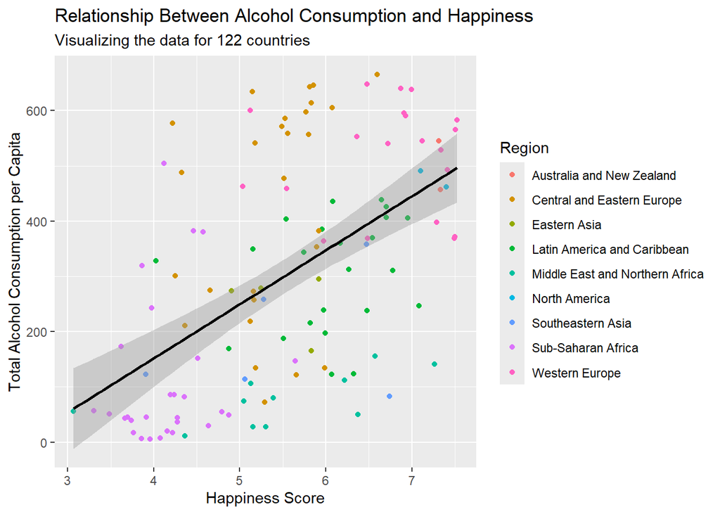

```r
# Create a scatter plot using ggplot2
ggplot(happiness_data_clean, aes(x = HappinessScore, y = TotalAlcohol, color = Region)) +
  geom_point() +
  labs(
    title = "Relationship Between Alcohol Consumption and Happiness",
    subtitle = "Visualizing the data for 122 countries",
    x = "Happiness Score",
    y = "Total Alcohol Consumption per Capita"
  ) +
  geom_smooth(method = "lm", color = "black")
```

### Interpretation of Results

The scatter plot above suggests a positive association between happiness and alcohol consumption. However, there is substantial variability in the data, implying that while a trend exists, it is not strongly deterministic.

Further analysis would be required to explore factors such as income levels, social structures, or cultural practices that may also influence these observations.

### Conclusion

This example has demonstrated the power of TidyVerse for cleaning, manipulating, and visualizing data. In particular, we used:

- `dplyr` for creating new variables and manipulating the dataset
- `tidyr` for handling missing values
- `ggplot2` for visualizing the relationship between happiness and alcohol consumption

To conclude, while we can see a general trend, the data reveals substantial variation between different regions, necessitating further exploration to draw robust conclusions.